# Project 1 - Data Visualization

Asher Dvir-Djerassi

**Principles of Data Visualization and Introduction to ggplot2**

I have provided you with data about the 5,000 fastest growing companies in the US, as compiled by Inc. magazine. lets read this in:

```r
inc <- read.csv("https://raw.githubusercontent.com/charleyferrari/CUNY_DATA_608/master/module1/Data/inc5000_data.csv", header= TRUE)

#Turn off scientific notation
options(scipen = 999)
#options(scipen = 0) #If you want to turn scientific notation on again
```

And lets preview this data:

```r
head(inc)
```

```
##   Rank                         Name Growth_Rate    Revenue
## 1    1                         Fuhu      421.48  117900000
## 2    2        FederalConference.com      248.31   49600000
## 3    3                The HCI Group      245.45   25500000
## 4    4                      Bridger      233.08 1900000000
## 5    5                       DataXu      213.37   87000000
## 6    6 MileStone Community Builders      179.38   45700000
##                       Industry Employees         City State
## 1 Consumer Products & Services       104   El Segundo    CA
## 2          Government Services        51     Dumfries    VA
## 3                       Health       132 Jacksonville    FL
## 4                       Energy        50      Addison    TX
## 5      Advertising & Marketing       220       Boston    MA
## 6                  Real Estate        63       Austin    TX
```

```r
summary(inc)
```

```
##       Rank                          Name       Growth_Rate
##  Min.   :   1   (Add)ventures         :   1   Min.   :  0.340
##  1st Qu.:1252   @Properties           :   1   1st Qu.:  0.770
##  Median :2502   1-Stop Translation USA:   1   Median :  1.420
##  Mean   :2502   110 Consulting        :   1   Mean   :  4.612
##  3rd Qu.:3751   11thStreetCoffee.com  :   1   3rd Qu.:  3.290
##  Max.   :5000   123 Exteriors         :   1   Max.   :421.480
##                 (Other)               :4995
##     Revenue                                    Industry
##  Min.   :    2000000   IT Services                 : 733
##  1st Qu.:    5100000   Business Products & Services: 482
##  Median :   10900000   Advertising & Marketing     : 471
##  Mean   :   48222535   Health                      : 355
##  3rd Qu.:   28600000   Software                    : 342
##  Max.   :10100000000   Financial Services          : 260
##                        (Other)                     :2358
##    Employees                  City          State
##  Min.   :    1.0   New York     : 160   CA     : 701
##  1st Qu.:   25.0   Chicago      :  90   TX     : 387
##  Median :   53.0   Austin       :  88   NY     : 311
##  Mean   :  232.7   Houston      :  76   VA     : 283
##  3rd Qu.:  132.0   San Francisco:  75   FL     : 282
##  Max.   :66803.0   Atlanta      :  74   IL     : 273
##  NA's   :12        (Other)      :4438   (Other):2764
```

Think a bit on what these summaries mean. Use the space below to add some more relevant non-visual exploratory information you think helps you understand this data:

Distribution and standard deviation of revenue

```r
summary(round(inc$Revenue))
```

```
##        Min.     1st Qu.      Median        Mean     3rd Qu.        Max.
##     2000000     5100000    10900000    48222535    28600000 10100000000
```

```r
sd(inc$Revenue)
```

```
## [1] 240542281
```

Distribution and standard deviation of employees

```r
summary(na.omit(round(inc$Employees)))
```

```
##    Min. 1st Qu.  Median    Mean 3rd Qu.    Max.
##     1.0    25.0    53.0   232.7   132.0 66803.0
```

```r
sd(na.omit(inc$Employees))
```

```
## [1] 1353.128
```

## Question 1

Create a graph that shows the distribution of companies in the dataset by State (i.e. how many are in each state). There are a lot of States, so consider which axis you should use. This visualization is ultimately going to be consumed on a ‘portrait’ oriented screen (i.e. taller than wide), which should further guide your layout choices.

```r
library(dplyr)
```

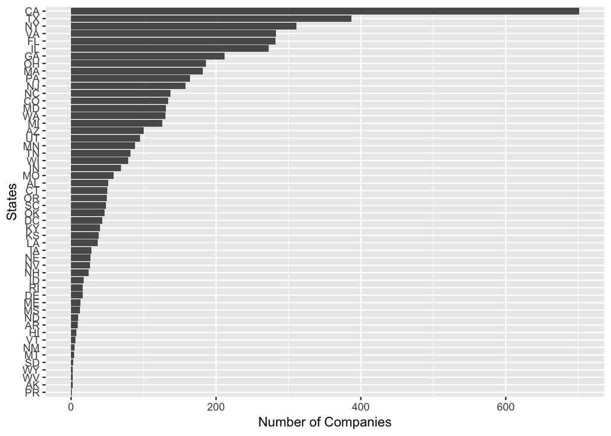

```r
library(ggplot2)

count(inc, State) %>%
  arrange(n) %>%
  mutate(State = factor(State, State)) %>%
  ggplot(aes(x=State, y=n)) +
  geom_bar(stat="identity") +
  coord_flip() +
  ylab("Number of Companies") +
  xlab("States")
```

## Quesiton 2

Lets dig in on the state with the 3rd most companies in the data set. Imagine you work for the state and are interested in how many people are employed by companies in different industries. Create a plot that shows the average and/or median employment by industry for companies in this state (only use cases with full data, use R’s `complete.cases()` function.) In addition to this, your graph should show how variable the ranges are, and you should deal with outliers.

```r
#State with 3rd most companies (i.e. New York)
library(dplyr)

#Mean by industry
df <- inc %>%
  group_by(Industry) %>%
  filter(State == "NY") %>%
  summarize(Mean = mean(Employees, na.rm=TRUE)); df
```

```
## # A tibble: 25 x 2
##    Industry                       Mean
##    <fct>                         <dbl>
##  1 Advertising & Marketing        58.4
##  2 Business Products & Services 1492.
##  3 Computer Hardware              44
##  4 Construction                   61
##  5 Consumer Products & Services  626.
##  6 Education                      59.9
##  7 Energy                        129.
##  8 Engineering                    53.5
##  9 Environmental Services        155
## 10 Financial Services            144.
## # ... with 15 more rows
```

```r
#Median by industry
df <- inc %>%
  group_by(Industry) %>%
  filter(State == "NY") %>%
  summarize(Median = median(Employees, na.rm=TRUE)); df
```

```
## # A tibble: 25 x 2
##    Industry                     Median
##    <fct>                         <dbl>
##  1 Advertising & Marketing        38
##  2 Business Products & Services   70.5
##  3 Computer Hardware              44
##  4 Construction                   24.5
##  5 Consumer Products & Services   25
##  6 Education                      50.5
##  7 Energy                        120
##  8 Engineering                    54.5
##  9 Environmental Services        155
## 10 Financial Services             81
## # ... with 15 more rows
```

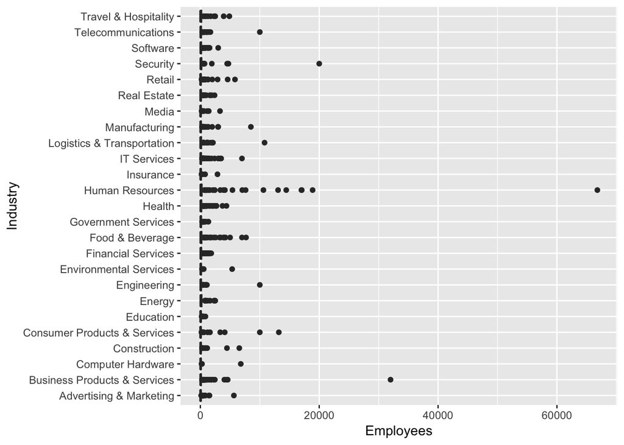

```r
#Boxplot of number of employees by industry
ggplot(inc, aes(x=Industry, y=Employees)) +
  geom_boxplot() +
  coord_flip()
```

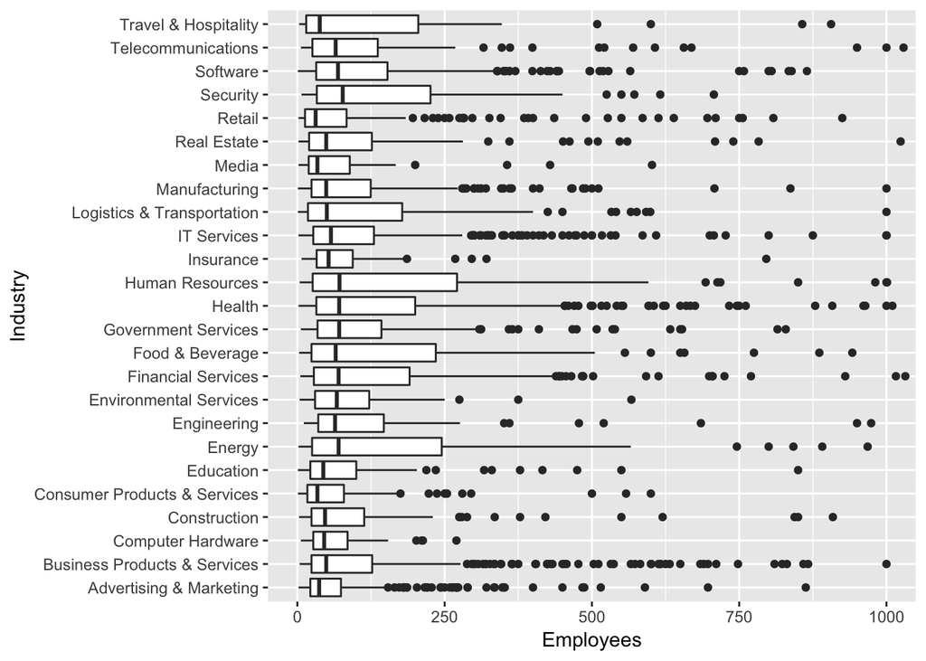

```r
#Zooming in (not restricting outlier): Boxplot of number of employees by industry. NOTE: I choose to not impose on the data by restricting outlier, rather this just zooms into the previous graph.
ggplot(inc, aes(x=Industry, y=Employees)) +
  geom_boxplot() +
  coord_flip(ylim = c(0,1000))
```

## Question 3

Now imagine you work for an investor and want to see which industries generate the most revenue per employee. Create a chart that makes this information clear. Once again, the distribution per industry should be shown.

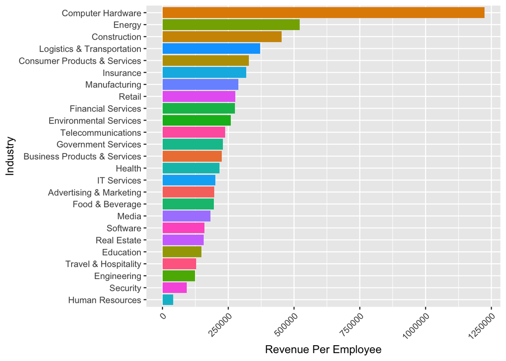

```r
df <- aggregate(inc[c(4,6)], by = list(inc$Industry), FUN = sum, na.rm=TRUE)

df$per_capita <- df$Revenue/df$Employees

ggplot(df, aes((x=reorder(Group.1, per_capita)), per_capita, group = Group.1, fill = Group.1)) +
  geom_bar(stat="identity")+
  theme(legend.position="none") +
  coord_flip()  +
  ylab("Revenue Per Employee") +
  xlab("Industry") +
  theme(axis.text.x = element_text(angle = 45, hjust = 1))
```